# Comparative methods in the tidyverse

## The tidyverse

The tidyverse is a collection of R packages that share a common philosophy and language for working with data.

Tidyverse packages are useful because they allow users to sort, filter, and merge data structures in a unified way.

However, things in the tidyverse can sometimes diverge from the normal way things are done in R.

You can [read more](https://www.tidyverse.org/) about the tidyverse.

## Trees and data in the tidyverse

Let’s get some example data and see what we can do.

```r
require(ape)
tree <- read.tree("Data/sampleTree.phy")
dat <- read.csv("Data/sampleData.csv")

# First notice some problems typical of comparative data
match(tree$tip.label, dat[,"taxa"])
```

```
##  [1]  1  2  3  4  5  6  7  8  9 10 11 12 13 14 15 16 17 18 19 20 21 22 23
## [24] 24 25 26 27 28 29 30 31 32 33 34 35 36 37 38 39 40 NA NA NA NA NA NA
## [47] NA NA NA NA
```

```r
# and
match(dat[,"taxa"], tree$tip.label)
```

```
##  [1]  1  2  3  4  5  6  7  8  9 10 11 12 13 14 15 16 17 18 19 20 21 22 23
## [24] 24 25 26 27 28 29 30 31 32 33 34 35 36 37 38 39 40 NA NA NA NA NA NA
## [47] NA NA NA NA
```

```r
# Now we can glue these two together to make a "treedata" object
require(treeplyr)
td <- make.treedata(tree, dat)
summary(td)
```

```
## A treeplyr treedata object
## The dataset contains  8  traits
## Continuous traits:  X X1 X2 X3 D3 XNA1
## Discrete traits:  D1 D2
## The following traits have missing values: XNA1
## These taxa were dropped from the tree: s51, s52, s53, s54, s55, s56, s57, s58, s59, s60
## These taxa were dropped from the data: s41, s42, s43, s44, s45, s46, s47, s48, s49, s50
## $phy
##
## Phylogenetic tree with 40 tips and 39 internal nodes.
##
## Tip labels:
##  s1, s2, s3, s4, s5, s6, ...
##
## Rooted; includes branch lengths.
##
## $dat
## # A tibble: 40 x 8
##        X     X1      X2     X3 D1       D2    D3  XNA1
##    <int>  <dbl>   <dbl>  <dbl> <fct> <int> <dbl> <dbl>
##  1     1 -0.543 -1.91   -0.177 World     1   0.3    NA
##  2     2  1.21   1.18    0.402 Hello     0   2.3    NA
##  3     3  1.16  -1.66   -0.732 World     0   2.3    NA
##  4     4  0.700 -0.464   0.830 World     0   0.3    NA
##  5     5  1.59  -1.12   -1.21  World     0   0.3    NA
##  6     6  0.558 -0.751  -1.05  World     0   0.3    NA
##  7     7 -1.28   2.09    1.44  Hello     0   1.3    NA
##  8     8 -0.573  0.0174 -1.02  Hello     0   1.3    NA
##  9     9 -1.22  -1.29    0.412 World     0   2.3    NA
## 10    10 -0.473 -1.64   -0.381 Hello     1   1.3    NA
## # … with 30 more rows
```

Notice that make.treedata performs a match using the “taxa” column, reporting back which tips were mismatched between the tree and data.

## Interacting with the treedata object

You can interact directly with parts of the treedata object if you want - but stay tuned for better ways to do most of this.

```r
# these work - but drop the tree
td[1:10, 2, tip.label=TRUE]
```

```
## # A tibble: 10 x 2
##    tip.label     X1
##    <fct>      <dbl>
##  1 s1        -0.543
##  2 s2         1.21
##  3 s3         1.16
##  4 s4         0.700
##  5 s5         1.59
##  6 s6         0.558
##  7 s7        -1.28
##  8 s8        -0.573
##  9 s9        -1.22
## 10 s10       -0.473
```

```r
td[[2]]
```

```
##          s1          s2          s3          s4          s5          s6
## -0.54252003  1.20786781  1.16040262  0.70021365  1.58683345  0.55848643
##          s7          s8          s9         s10         s11         s12
## -1.27659221 -0.57326541 -1.22461261 -0.47340064 -0.62036668  0.04211587
##         s13         s14         s15         s16         s17         s18
## -0.91092165  0.15802877 -0.65458464  1.76728727  0.71670748  0.91017423
##         s19         s20         s21         s22         s23         s24
##  0.38418536  1.68217608 -0.63573645 -0.46164473  1.43228224 -0.65069635
##         s25         s26         s27         s28         s29         s30
## -0.20738074 -0.39280793 -0.31999287 -0.27911330  0.49418833 -0.17733048
##         s31         s32         s33         s34         s35         s36
## -0.50595746  1.34303883 -0.21457941 -0.17955653 -0.10019074  0.71266631
##         s37         s38         s39         s40
## -0.07356440 -0.03763417 -0.68166048 -0.32427027
```

```r
td[['X1']]
```

```
##          s1          s2          s3          s4          s5          s6
## -0.54252003  1.20786781  1.16040262  0.70021365  1.58683345  0.55848643
##          s7          s8          s9         s10         s11         s12
## -1.27659221 -0.57326541 -1.22461261 -0.47340064 -0.62036668  0.04211587
##         s13         s14         s15         s16         s17         s18
## -0.91092165  0.15802877 -0.65458464  1.76728727  0.71670748  0.91017423
##         s19         s20         s21         s22         s23         s24
##  0.38418536  1.68217608 -0.63573645 -0.46164473  1.43228224 -0.65069635
##         s25         s26         s27         s28         s29         s30
## -0.20738074 -0.39280793 -0.31999287 -0.27911330  0.49418833 -0.17733048
##         s31         s32         s33         s34         s35         s36
## -0.50595746  1.34303883 -0.21457941 -0.17955653 -0.10019074  0.71266631
##         s37         s38         s39         s40
## -0.07356440 -0.03763417 -0.68166048 -0.32427027
```

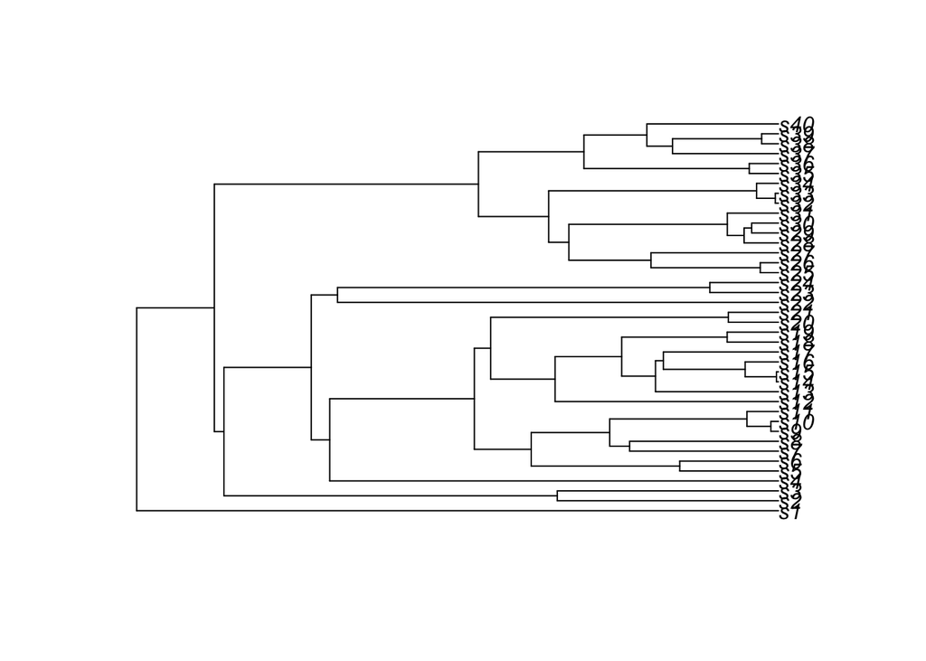

```r
# this works as well
plot(td$phy)
```

```r
# better way to extract columns that retains tip labels
getVector(td, X1)
```

```
##          s1          s2          s3          s4          s5          s6
## -0.54252003  1.20786781  1.16040262  0.70021365  1.58683345  0.55848643
##          s7          s8          s9         s10         s11         s12
## -1.27659221 -0.57326541 -1.22461261 -0.47340064 -0.62036668  0.04211587
##         s13         s14         s15         s16         s17         s18
## -0.91092165  0.15802877 -0.65458464  1.76728727  0.71670748  0.91017423
##         s19         s20         s21         s22         s23         s24
##  0.38418536  1.68217608 -0.63573645 -0.46164473  1.43228224 -0.65069635
##         s25         s26         s27         s28         s29         s30
## -0.20738074 -0.39280793 -0.31999287 -0.27911330  0.49418833 -0.17733048
##         s31         s32         s33         s34         s35         s36
## -0.50595746  1.34303883 -0.21457941 -0.17955653 -0.10019074  0.71266631
##         s37         s38         s39         s40
## -0.07356440 -0.03763417 -0.68166048 -0.32427027
```

```r
getVector(td, D2)
```

```
##  s1  s2  s3  s4  s5  s6  s7  s8  s9 s10 s11 s12 s13 s14 s15 s16 s17 s18
##   1   0   0   0   0   0   0   0   0   1   0   1   1   0   0   0   1   0
## s19 s20 s21 s22 s23 s24 s25 s26 s27 s28 s29 s30 s31 s32 s33 s34 s35 s36
##   1   1   1   1   0   1   1   0   0   0   1   1   1   0   0   1   1   1
## s37 s38 s39 s40
##   0   1   0   1
```

## Working in the tidyverse - some highlights

*Select*

Select allows you to choose certain columns in the data matrix. Since columns are being chosen nothing happens to the tree.

```r
td_s1 <- select(td, X1, D1)
summary(td_s1)
```

```
## A treeplyr treedata object
## The dataset contains  2  traits
## Continuous traits:  X1
## Discrete traits:  D1
## The following traits have missing values:
## These taxa were dropped from the tree: s51, s52, s53, s54, s55, s56, s57, s58, s59, s60
## These taxa were dropped from the data: s41, s42, s43, s44, s45, s46, s47, s48, s49, s50
## $phy
##
## Phylogenetic tree with 40 tips and 39 internal nodes.
##
## Tip labels:
##  s1, s2, s3, s4, s5, s6, ...
##
## Rooted; includes branch lengths.
##
## $dat
## # A tibble: 40 x 2
##        X1 D1
##     <dbl> <fct>
##  1 -0.543 World
##  2  1.21  Hello
##  3  1.16  World
##  4  0.700 World
##  5  1.59  World
##  6  0.558 World
##  7 -1.28  Hello
##  8 -0.573 Hello
##  9 -1.22  World
## 10 -0.473 Hello
## # … with 30 more rows
```

```r
head(td_s1$dat)
```

```
## # A tibble: 6 x 2
##       X1 D1
##    <dbl> <fct>
## 1 -0.543 World
## 2  1.21  Hello
## 3  1.16  World
## 4  0.700 World
## 5  1.59  World
## 6  0.558 World
```

```r
td_s2<-select(td, 1:3)
summary(td_s2)
```

```
## A treeplyr treedata object
## The dataset contains  3  traits
## Continuous traits:  X X1 X2
## Discrete traits:
## The following traits have missing values:
## These taxa were dropped from the tree: s51, s52, s53, s54, s55, s56, s57, s58, s59, s60
## These taxa were dropped from the data: s41, s42, s43, s44, s45, s46, s47, s48, s49, s50
## $phy
##
## Phylogenetic tree with 40 tips and 39 internal nodes.
##
## Tip labels:
##  s1, s2, s3, s4, s5, s6, ...
##
## Rooted; includes branch lengths.
##
## $dat
## # A tibble: 40 x 3
##        X     X1      X2
##    <int>  <dbl>   <dbl>
##  1     1 -0.543 -1.91
##  2     2  1.21   1.18
##  3     3  1.16  -1.66
##  4     4  0.700 -0.464
##  5     5  1.59  -1.12
##  6     6  0.558 -0.751
##  7     7 -1.28   2.09
##  8     8 -0.573  0.0174
##  9     9 -1.22  -1.29
## 10    10 -0.473 -1.64
## # … with 30 more rows
```

```r
td_s3<-select(td, 1, 4, 6)
summary(td_s3)
```

```
## A treeplyr treedata object
## The dataset contains  3  traits
## Continuous traits:  X X3
## Discrete traits:  D2
## The following traits have missing values:
## These taxa were dropped from the tree: s51, s52, s53, s54, s55, s56, s57, s58, s59, s60
## These taxa were dropped from the data: s41, s42, s43, s44, s45, s46, s47, s48, s49, s50
## $phy
##
## Phylogenetic tree with 40 tips and 39 internal nodes.
##
## Tip labels:
##  s1, s2, s3, s4, s5, s6, ...
##
## Rooted; includes branch lengths.
##
## $dat
## # A tibble: 40 x 3
##        X     X3    D2
##    <int>  <dbl> <int>
##  1     1 -0.177     1
##  2     2  0.402     0
##  3     3 -0.732     0
##  4     4  0.830     0
##  5     5 -1.21      0
##  6     6 -1.05      0
##  7     7  1.44      0
##  8     8 -1.02      0
##  9     9  0.412     0
## 10    10 -0.381     1
## # … with 30 more rows
```

You can also use the fancy tools from dplyr as arguments to “select.”

```r
td_s4<-select(td, starts_with("D"))
td_s4
```

```
## $phy
##
## Phylogenetic tree with 40 tips and 39 internal nodes.
##
## Tip labels:
##  s1, s2, s3, s4, s5, s6, ...
##
## Rooted; includes branch lengths.
##
## $dat
## # A tibble: 40 x 3
##    D1       D2    D3
##    <fct> <int> <dbl>
##  1 World     1   0.3
##  2 Hello     0   2.3
##  3 World     0   2.3
##  4 World     0   0.3
##  5 World     0   0.3
##  6 World     0   0.3
##  7 Hello     0   1.3
##  8 Hello     0   1.3
##  9 World     0   2.3
## 10 Hello     1   1.3
## # … with 30 more rows
```

```r
td_s5<-select(td, ends_with("1"))
td_s5
```

```
## $phy
##
## Phylogenetic tree with 40 tips and 39 internal nodes.
##
## Tip labels:
##  s1, s2, s3, s4, s5, s6, ...
##
## Rooted; includes branch lengths.
##
## $dat
## # A tibble: 40 x 3
##        X1 D1     XNA1
##     <dbl> <fct> <dbl>
##  1 -0.543 World    NA
##  2  1.21  Hello    NA
##  3  1.16  World    NA
##  4  0.700 World    NA
##  5  1.59  World    NA
##  6  0.558 World    NA
##  7 -1.28  Hello    NA
##  8 -0.573 Hello    NA
##  9 -1.22  World    NA
## 10 -0.473 Hello    NA
## # … with 30 more rows
```

```r
td_s6<-select(td, matches("NA"))
td_s6
```

```
## $phy
##
## Phylogenetic tree with 40 tips and 39 internal nodes.
##
## Tip labels:
##  s1, s2, s3, s4, s5, s6, ...
##
## Rooted; includes branch lengths.
##
## $dat
## # A tibble: 40 x 1
##     XNA1
##    <dbl>
##  1    NA
##  2    NA
##  3    NA
##  4    NA
##  5    NA
##  6    NA
##  7    NA
##  8    NA
##  9    NA
## 10    NA
## # … with 30 more rows
```

```r
td_s7<-select(td, -matches("NA"))
td_s7
```

```
## $phy
##
## Phylogenetic tree with 40 tips and 39 internal nodes.
##
## Tip labels:
##  s1, s2, s3, s4, s5, s6, ...
##
## Rooted; includes branch lengths.
##
## $dat
## # A tibble: 40 x 7
##        X     X1      X2     X3 D1       D2    D3
##    <int>  <dbl>   <dbl>  <dbl> <fct> <int> <dbl>
##  1     1 -0.543 -1.91   -0.177 World     1   0.3
##  2     2  1.21   1.18    0.402 Hello     0   2.3
##  3     3  1.16  -1.66   -0.732 World     0   2.3
##  4     4  0.700 -0.464   0.830 World     0   0.3
##  5     5  1.59  -1.12   -1.21  World     0   0.3
##  6     6  0.558 -0.751  -1.05  World     0   0.3
##  7     7 -1.28   2.09    1.44  Hello     0   1.3
##  8     8 -0.573  0.0174 -1.02  Hello     0   1.3
##  9     9 -1.22  -1.29    0.412 World     0   2.3
## 10    10 -0.473 -1.64   -0.381 Hello     1   1.3
## # … with 30 more rows
```

```r
td_s8<-select(td, -starts_with("X"))
td_s8
```

```
## $phy
##
## Phylogenetic tree with 40 tips and 39 internal nodes.
##
## Tip labels:
##  s1, s2, s3, s4, s5, s6, ...
##
## Rooted; includes branch lengths.
##
## $dat
## # A tibble: 40 x 3
##    D1       D2    D3
##    <fct> <int> <dbl>
##  1 World     1   0.3
##  2 Hello     0   2.3
##  3 World     0   2.3
##  4 World     0   0.3
##  5 World     0   0.3
##  6 World     0   0.3
##  7 Hello     0   1.3
##  8 Hello     0   1.3
##  9 World     0   2.3
## 10 Hello     1   1.3
## # … with 30 more rows
```

*Filter*

Filter allows you to choose certain rows in the data matrix. Since rows are selected then tips in the tree are also pruned accordingly.

```r
td_f1<-filter(td, X1 > 0, D1=="Hello", is.na(XNA1)==FALSE)
td_f1
```

```
## $phy
##
## Phylogenetic tree with 6 tips and 5 internal nodes.
##
## Tip labels:
## [1] "s14" "s16" "s17" "s20" "s32" "s36"
##
## Rooted; includes branch lengths.
##
## $dat
## # A tibble: 6 x 8
##       X    X1      X2       X3 D1       D2    D3   XNA1
##   <int> <dbl>   <dbl>    <dbl> <fct> <int> <dbl>  <dbl>
## 1    14 0.158 -0.929  -0.331   Hello     0   0.3 -1.29
## 2    16 1.77  -1.08    2.50    Hello     0   1.3  1.31
## 3    17 0.717  1.00    0.667   Hello     1   0.3  1.50
## 4    20 1.68   1.87    0.510   Hello     1   1.3  0.482
## 5    32 1.34   0.106   0.00213 Hello     0   1.3  0.947
## 6    36 0.713 -0.0347  1.80    Hello     1   1.3  0.740
```

```r
td_f2<-filter(td, X1 + X2 > 0 & D1 == "Hello")
td_f2
```

```
## $phy
##
## Phylogenetic tree with 9 tips and 8 internal nodes.
##
## Tip labels:
##  s2, s7, s16, s17, s20, s32, ...
##
## Rooted; includes branch lengths.
##
## $dat
## # A tibble: 9 x 8
##       X     X1      X2       X3 D1       D2    D3     XNA1
##   <int>  <dbl>   <dbl>    <dbl> <fct> <int> <dbl>    <dbl>
## 1     2  1.21   1.18    0.402   Hello     0   2.3 NA
## 2     7 -1.28   2.09    1.44    Hello     0   1.3 NA
## 3    16  1.77  -1.08    2.50    Hello     0   1.3  1.31
## 4    17  0.717  1.00    0.667   Hello     1   0.3  1.50
## 5    20  1.68   1.87    0.510   Hello     1   1.3  0.482
## 6    32  1.34   0.106   0.00213 Hello     0   1.3  0.947
## 7    33 -0.215  0.457  -0.630   Hello     0   0.3  0.00440
## 8    36  0.713 -0.0347  1.80    Hello     1   1.3  0.740
## 9    39 -0.682  1.03    0.197   Hello     0   2.3 -0.289
```

*Mutate*

```r
td_m1<-mutate(td, Xall = (X1+X2+X3)/3, D1.binary = as.numeric(D1)-1)
summary(td_m1)
```

```
## A treeplyr treedata object
## The dataset contains  10  traits
## Continuous traits:  X X1 X2 X3 D3 XNA1 Xall
## Discrete traits:  D1 D2 D1.binary
## The following traits have missing values: XNA1
## These taxa were dropped from the tree: s51, s52, s53, s54, s55, s56, s57, s58, s59, s60
## These taxa were dropped from the data: s41, s42, s43, s44, s45, s46, s47, s48, s49, s50
## $phy
##
## Phylogenetic tree with 40 tips and 39 internal nodes.
##
## Tip labels:
##  s1, s2, s3, s4, s5, s6, ...
##
## Rooted; includes branch lengths.
##
## $dat
## # A tibble: 40 x 10
##        X     X1      X2     X3 D1       D2    D3  XNA1   Xall D1.binary
##    <int>  <dbl>   <dbl>  <dbl> <fct> <int> <dbl> <dbl>  <dbl>     <dbl>
##  1     1 -0.543 -1.91   -0.177 World     1   0.3    NA -0.878         1
##  2     2  1.21   1.18    0.402 Hello     0   2.3    NA  0.929         0
##  3     3  1.16  -1.66   -0.732 World     0   2.3    NA -0.412         1
##  4     4  0.700 -0.464   0.830 World     0   0.3    NA  0.356         1
##  5     5  1.59  -1.12   -1.21  World     0   0.3    NA -0.246         1
##  6     6  0.558 -0.751  -1.05  World     0   0.3    NA -0.413         1
##  7     7 -1.28   2.09    1.44  Hello     0   1.3    NA  0.751         0
##  8     8 -0.573  0.0174 -1.02  Hello     0   1.3    NA -0.524         0
##  9     9 -1.22  -1.29    0.412 World     0   2.3    NA -0.700         1
## 10    10 -0.473 -1.64   -0.381 Hello     1   1.3    NA -0.832         0
## # … with 30 more rows
```

```r
td_m1[c("Xall", "D1.binary")]
```

```
## # A tibble: 40 x 2
##      Xall D1.binary
##     <dbl>     <dbl>
##  1 -0.878         1
##  2  0.929         0
##  3 -0.412         1
##  4  0.356         1
##  5 -0.246         1
##  6 -0.413         1
##  7  0.751         0
##  8 -0.524         0
##  9 -0.700         1
## 10 -0.832         0
## # … with 30 more rows
```

## Using treeplyr to run functions over trees

You can run r functions on treeplyr objects in a straightforward way using standard R:

```r
require(phytools)
```

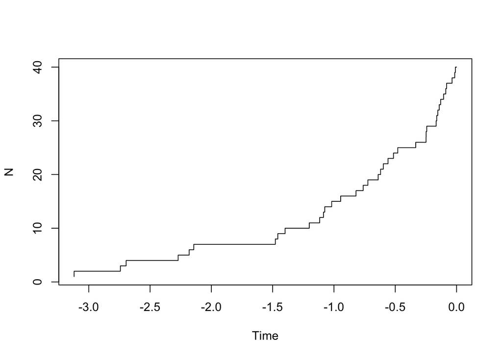

```r
ltt.plot(td$phy)
```

```r
phylosig(td$phy, getVector(td, X1))
```

```
## [1] 0.05983494
```

But there is a nifty way to do this using treedply, made specifically to run functions on a treedata object:

```r
treedply(td, phylosig(phy, getVector(td, X1), "K"))
```

```
## [1] 0.05983494
```

```r
treedply(td, list("K" = phylosig(phy, getVector(td, X1), "K"), "lambda" = phylosig(phy, getVector(td, X1),"lambda")))
```

```
## $K
## [1] 0.05983494
##
## $lambda
## $lambda$lambda
## [1] 7.351765e-05
##
## $lambda$logL
## [1] -48.07617
```

There are also “apply” functions from treedata objects, which allow us to easily iterate comparative methods across characters. treeplyr has some functions to make sure you know which characters you are dealing with.

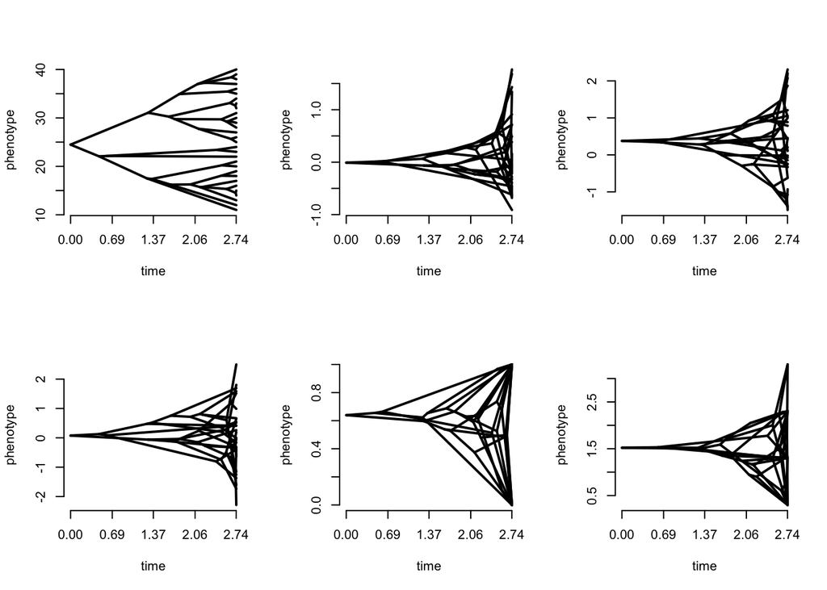

[output not shown]

[output cut: 46 more lines]

```r
tdDiscrete <- forceFactor(td)
tdNumeric <- forceNumeric(td)
tdNumeric <- filter(tdNumeric, !is.na(XNA1))


par(mfrow=c(2,3))
tdapply(tdNumeric, 2, phytools::phenogram, tree=phy, spread.labels=FALSE, ftype="off")
```

```r
fitsBM <- tdapply(tdNumeric, 2, geiger::fitContinuous, phy=phy, model="BM")
sapply(fitsBM, function(x) x$opt$sigsq)
```

```
##          X         X1         X2         X3         D2         D3
## 13.2382194  5.3712587  3.9081367 11.1951598  0.9168851 19.4370364
##       XNA1
##  8.8442750
```

[figure not shown]

There is also a function that iterates over the phylogeney part of the treedata object.

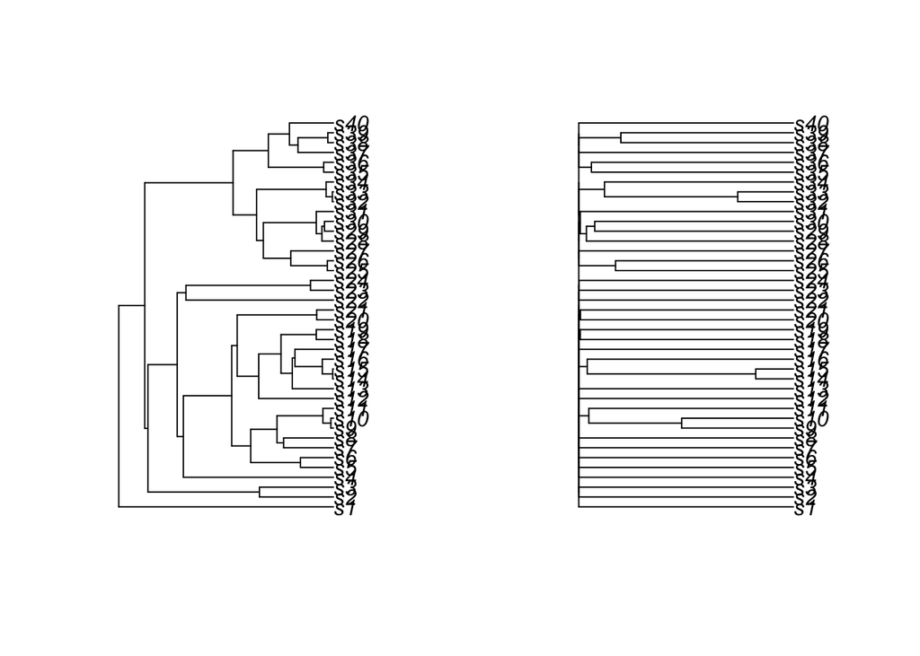

```r
td.OU10 <- treeply(td, geiger::rescale, model="OU", 10)
par(mfrow=c(1,2))
plot(td$phy)
plot(td.OU10$phy)
```

```r
treeply(td, drop.tip, c(1:35))
```

```
## $phy
##
## Phylogenetic tree with 5 tips and 4 internal nodes.
##
## Tip labels:
## [1] "s36" "s37" "s38" "s39" "s40"
##
## Rooted; includes branch lengths.
##
## $dat
## # A tibble: 5 x 8
##       X      X1      X2     X3 D1       D2    D3   XNA1
##   <int>   <dbl>   <dbl>  <dbl> <fct> <int> <dbl>  <dbl>
## 1    36  0.713  -0.0347  1.80  Hello     1   1.3  0.740
## 2    37 -0.0736  0.788  -0.331 World     0   0.3 -1.06
## 3    38 -0.0376  2.08   -1.61  World     1   0.3  0.246
## 4    39 -0.682   1.03    0.197 Hello     0   2.3 -0.289
## 5    40 -0.324   1.21    0.263 World     1   0.3 -2.26
```

## Grouping tree tips

```r
td.D1 <- group_by(td, D1)
summarize(td.D1, mean(X1), sd(X1), mean(X2), sd(X2))
```

```
##      D1   mean.X1.    sd.X1.    mean.X2.   sd.X2.
## 1 Hello 0.09735458 0.9546852  0.10771534 1.089466
## 2 World 0.07318464 0.7174964 -0.01201879 1.231206
```

```r
summarise(td.D1, ntips = length(phy$tip.label),
            psig.X1 = phytools::phylosig(setNames(X1, phy$tip.label), tree=phy),
              psig.X2 = phytools::phylosig(setNames(X2, phy$tip.label), tree=phy))
```

```
##      D1 ntips    psig.X1   psig.X2
## 1 Hello    17 0.05241561 0.2112923
## 2 World    23 0.29027126 0.3809347
```

```r
summarise(td.D1, ntips = length(phy$tip.label),
              totalTL = sum(phy$edge.length), varianceBL = var(phy$edge.length))
```

```
##      D1 ntips  totalTL varianceBL
## 1 Hello    17 18.23593  0.3182517
## 2 World    23 30.73710  0.5296092
```

```r
summarise(td.D1, sigsq = geiger::fitContinuous(phy, setNames(X1, phy$tip.label))$opt$sigsq,
                 root = geiger::fitContinuous(phy, setNames(X1, phy$tip.label))$opt$z0)
```

```
##      D1     sigsq       root
## 1 Hello 7.9724838 0.36027556
## 2 World 0.6679094 0.04721332
```

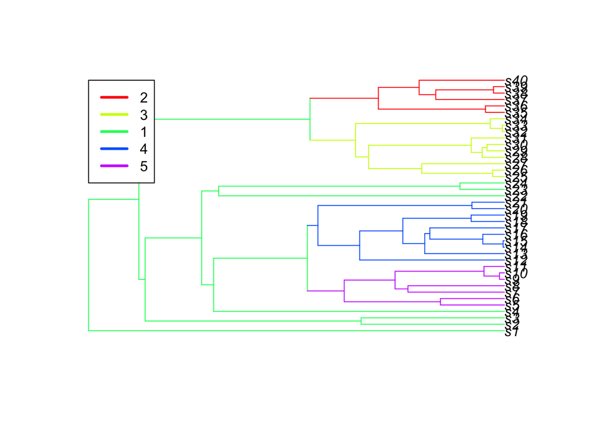

```r
td.painted <- paint_clades(td, interactive=FALSE, type="nodes", ids=c(75, 66, 54, 48), plot=TRUE)
```

```r
td.painted <- group_by(td.painted, clades)
summarise(td.painted, psig1 = phytools::phylosig(setNames(X1, phy$tip.label), tree=phy),
          meanX1 = mean(X1), sdX1 = sd(X1), ntips =length(phy$tip.label))
```

```
##   clades      psig1      meanX1      sdX1 ntips
## 1      1 0.27062158  0.40655789 0.9238538     7
## 2      2 0.27862586 -0.08410896 0.4587212     6
## 3      3 0.03721839 -0.04394916 0.5549763    10
## 4      4 0.12079308  0.34594323 0.9389773    10
## 5      5 0.60748135 -0.28898824 1.0256955     7
```

(there is also an interactive mode)